# MonteCarlo test

Juan A. Dominguez J.

19/9/2018

## Introducion

This document contains the info related to the session about some introductory examples for understanding the Montecarlo simulation method. This one is a tool to learn basic concepts in statistics & probability.

The Montecarlo method falls under the rubric of **Parametric bootstrap** that is quite different than the **non-parametric bootstrap**, which uses resampling of the original data to generate empirical sampling distributions

##### Importing the library

```r
library(MonteCarlo)
```

##### Generating random numbers

Generating 1000 random numbers by using one of the many useful facilities that R offer to us.

```r
runif(n=1000,min=0,max=1)
```

Ok, so now is pretty interesant to look the behaviour of these generated data. By using the `par()` function

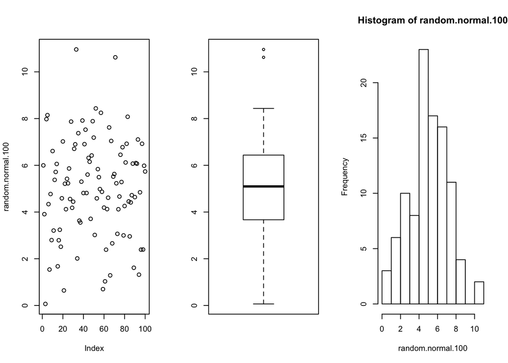

```r
#If we wanted to look at 100 draws from a normal distribution with u=5 and std=2, e.g. N(5,2)
random.normal.100 <- rnorm(n=100,mean=5,sd=2)
#The par function is useful when we need to modify low-level plotting funcionts
par(mfrow=c(1,3))
plot(random.normal.100)
boxplot(random.normal.100)
hist(random.normal.100)
```

##### Look at the mean and std computed

```r
mean(random.normal.100)
```

```
## [1] 5.020995
```

```r
sd(random.normal.100)
```

```
## [1] 2.126117
```

*Results are closed to the theoretical ones establisteds*

Now if we want to make more than just one simulation, let’s use the `replicate` fucntion. In this case, we will replicate them by 5 times.

```r
random.normal.100.rep <- replicate(n=5,rnorm(100,5,2))
```

Several times!!

```r
par(mfrow=c(2,2))
#Apply() allow us to call several times one specific function (hist, mean, sd) by columns (MARGIN = 2), if this one would 1, it means Rows.
apply(X=random.normal.100.rep, MARGIN = 2, FUN= hist)
apply(X=random.normal.100.rep, MARGIN = 2, FUN= mean)
apply(X=random.normal.100.rep, MARGIN = 2, FUN= sd)
```

[output not shown]

Summarizing them

```r
summary(random.normal.100.rep)
```

```
##        V1                 V2               V3               V4
##  Min.   : 0.02323   Min.   :0.5206   Min.   :-1.116   Min.   :0.4734
##  1st Qu.: 4.41313   1st Qu.:3.4647   1st Qu.: 3.908   1st Qu.:3.9102
##  Median : 5.38253   Median :4.6215   Median : 5.040   Median :5.4676
##  Mean   : 5.44418   Mean   :4.7006   Mean   : 5.054   Mean   :5.2967
##  3rd Qu.: 6.47175   3rd Qu.:5.9726   3rd Qu.: 6.530   3rd Qu.:6.7640
##  Max.   :11.51518   Max.   :8.6483   Max.   :10.076   Max.   :9.3900
##        V5
##  Min.   :-1.045
##  1st Qu.: 3.662
##  Median : 4.641
##  Mean   : 4.675
##  3rd Qu.: 6.235
##  Max.   : 9.758
```

So, let’s compute the SD among these results

```r
sd(apply(random.normal.100.rep,2,mean))
```

```
[1] 0.3455901
```

*Results show that there is not so much SD among data*

##### Let’s repeat but in this case with a lower sample (25)

```r
nom.sim.25 <- replicate(n=5,rnorm(25,5,2))
sd(apply(nom.sim.25,2,mean))
```

```
[1] 0.5124212
```

##### Let’s repeat but in this case with a larger sample (1000)

```r
nom.sim.1000 <- replicate(n=5,rnorm(1000,5,2))
sd(apply(nom.sim.1000,2,mean))
```

```
[1] 0.06550009
```

At this moment, we have just learned about Montecarlo method. It was clear that when we perform simulations specially with distributions , as our n increases we will get closer to the expected value.